# Assignment 3: Model comparison

#### Checking assumptions of the updated model

Normality assumption

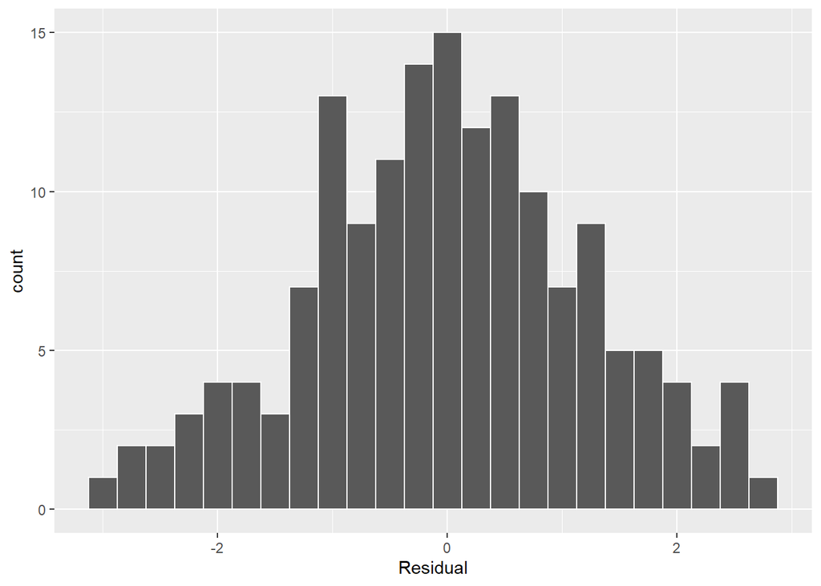

```r
# Plotting the distribution of the residuals in the updated complex model to see whether the residuals have a normal distribution
ggplot(assignment_3_dataset_updmodel, aes(x = residuals)) +
  geom_histogram(binwidth = 0.25, color = "white") +
  labs(x = "Residual")
```

**The histogram shows a fairly normal distribution of the residuals.**

Linearity assumption

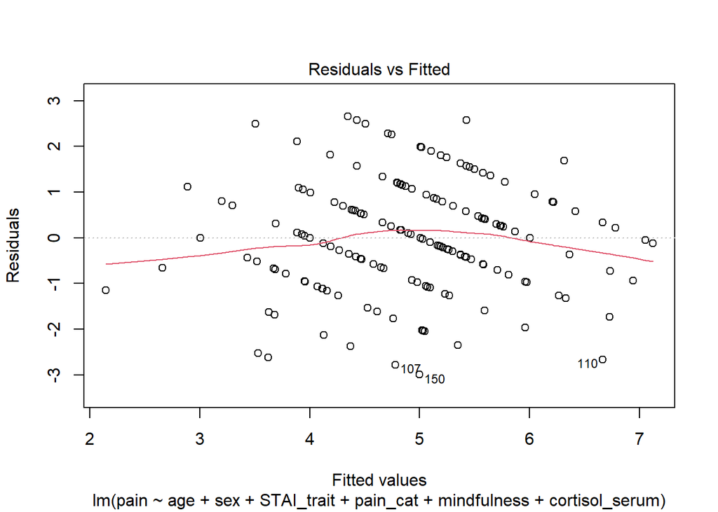

```r
# Checking linearity
plot(complex_model_upd, 1) # Although there is a small curve for the fitted line on the plot, it does not seem to violate the assumption of linearity significantly
```

**Although there is a small curve for the fitted line on the plot, it does not seem to violate the assumption of linearity significantly.**

Homoscedasticty assumption (homogeneity of variance)

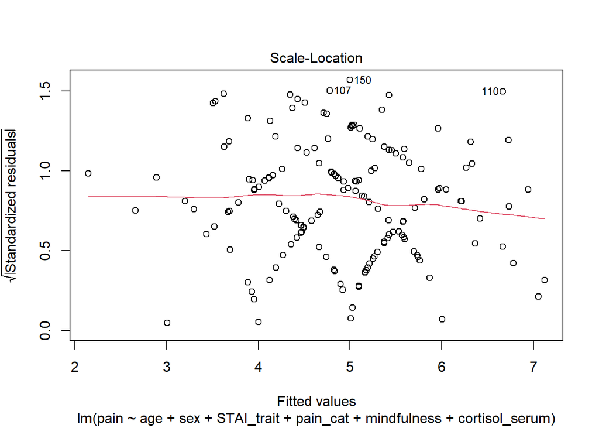

```r
# Checking homoscedasticity
plot(complex_model_upd, 3) # The plot shows that the homoscedasticity assumption is met
```

**The plot shows that the homoscedasticity assumption is met.**

Multicollinearity assumption

```r
# Calculating the VIF for the updated complex model
vif(complex_model_upd)
```

```
##            age            sex     STAI_trait       pain_cat    mindfulness
##       1.401789       1.143716       1.939585       1.865332       1.519361
## cortisol_serum
##       1.527112
```

```r
# Calculating tolerance
1/vif(complex_model_upd)
```

```
##            age            sex     STAI_trait       pain_cat    mindfulness
##      0.7133741      0.8743431      0.5155743      0.5360976      0.6581712
## cortisol_serum
##      0.6548308
```

**All VIF and tolerance values are acceptable, there is no problem with multicollinearity.**

## Model comparison

Create the simple model and get the results of the model that needs to be reported based on the What to report section.

```r
# Creating the simple model
simple_model  <- lm(pain ~ age+ sex, data=assignment_3_dataset)
```

Create the more complex model based on the results of the model diagnostics. Also, get the results that needs to be reported based on the What to report section.

```r
# The final model is the updated model
summary(complex_model_upd)
```

```
##
## Call:
## lm(formula = pain ~ age + sex + STAI_trait + pain_cat + mindfulness +
##     cortisol_serum, data = assignment_3_dataset)
##
## Residuals:
##      Min       1Q   Median       3Q      Max
## -2.99671 -0.78931 -0.00646  0.79467  2.65588
##
## Coefficients:
##                Estimate Std. Error t value Pr(>|t|)
## (Intercept)     1.98983    1.69003   1.177  0.24087
## age            -0.03597    0.02320  -1.550  0.12316
## sexmale         0.31262    0.21101   1.482  0.14052
## STAI_trait     -0.01144    0.02673  -0.428  0.66936
## pain_cat        0.08465    0.02825   2.996  0.00319 **
## mindfulness    -0.14668    0.12469  -1.176  0.24129
## cortisol_serum  0.53411    0.12317   4.336 2.62e-05 ***
## ---
## Signif. codes:  0 '***' 0.001 '**' 0.01 '*' 0.05 '.' 0.1 ' ' 1
##
## Residual standard error: 1.246 on 153 degrees of freedom
## Multiple R-squared:  0.352,  Adjusted R-squared:  0.3266
## F-statistic: 13.85 on 6 and 153 DF,  p-value: 1.516e-12
```

```r
summary(simple_model)
```

```
##
## Call:
## lm(formula = pain ~ age + sex, data = assignment_3_dataset)
##
## Residuals:
##     Min      1Q  Median      3Q     Max
## -3.6636 -0.9701  0.1464  1.0487  3.5026
##
## Coefficients:
##             Estimate Std. Error t value Pr(>|t|)
## (Intercept)  8.49265    0.94523   8.985 7.74e-16 ***
## age         -0.08905    0.02297  -3.876 0.000155 ***
## sexmale      0.10095    0.23128   0.436 0.663075
## ---
## Signif. codes:  0 '***' 0.001 '**' 0.01 '*' 0.05 '.' 0.1 ' ' 1
##
## Residual standard error: 1.46 on 157 degrees of freedom
## Multiple R-squared:  0.08779,    Adjusted R-squared:  0.07617
## F-statistic: 7.555 on 2 and 157 DF,  p-value: 0.0007371
```

```r
## Obtaining Beta values and confidence intervals
lm.beta(complex_model_upd)
```

```
##            age        sexmale     STAI_trait       pain_cat    mindfulness
##    -0.11944164             NA    -0.03877789     0.26629962    -0.09436139
## cortisol_serum
##     0.34872559
```

```r
lm.beta(simple_model)
```

```
##        age    sexmale
## -0.2956999         NA
```

```r
confint(complex_model_upd)
```

```
##                      2.5 %      97.5 %
## (Intercept)    -1.34897451 5.328641619
## age            -0.08180773 0.009870531
## sexmale        -0.10424931 0.729488979
## STAI_trait     -0.06423726 0.041366443
## pain_cat        0.02883494 0.140472876
## mindfulness    -0.39302441 0.099660881
## cortisol_serum  0.29077120 0.777445224
```

```r
confint(simple_model)
```

```
##                  2.5 %      97.5 %
## (Intercept)  6.6256508 10.35965581
## age         -0.1344199 -0.04367399
## sexmale     -0.3558649  0.55776969
```

### Table of results

#### Model Test Statistics

| Models | Adjusted R-squared | F | df | p |
| --- | --- | --- | --- | --- |
| Simple Model | 0,076 | 7,555 | 157 | <0,001 |
| Complex Model | 0,326 | 13,85 | 153 | <0,001 |

#### Predictors in simple model

| Predictors | b (unstandardized coefficient) | 95% CI lower bound | 95% CI upper bound | Beta (standardized coefficient) | p |
| --- | --- | --- | --- | --- | --- |
| Intercept | 8,49 | 6,63 | 10,36 | - | <0,001 |
| Age | -0,09 | -0,13 | -0,04 | -0,3 | <0,001 |
| Sexmale | 0,1 | -0,36 | 0,56 | NA | 0,66 |

#### Predictors in complex model

[output not shown]

**Regression equation for the complex model: pain = b0 + b1 X age + b2 X sexmale + b3 X STAI_trait + b4 X pain_cat + b5 X mindfulness + b6 X cortisol_serum=1.98 -0.036 X age + 0.31 X sexmale -0.011 X STAI_trait + 0.084 X pain_cat -0.15 X mindfulness + 0.53 X cortisol_serum**

Compare the two models.

```r
# Comparing the two model
anova(simple_model, complex_model_upd) #
```

```
## Analysis of Variance Table
##
## Model 1: pain ~ age + sex
## Model 2: pain ~ age + sex + STAI_trait + pain_cat + mindfulness + cortisol_serum
##   Res.Df    RSS Df Sum of Sq      F    Pr(>F)
## 1    157 334.58
## 2    153 237.66  4    96.919 15.599 1.003e-10 ***
## ---
## Signif. codes:  0 '***' 0.001 '**' 0.01 '*' 0.05 '.' 0.1 ' ' 1
```

```r
AIC(complex_model_upd, simple_model)
```

```
##                   df      AIC
## complex_model_upd  8 533.3656
## simple_model       4 580.0909
```

Discussion: In your discussion of the findings, briefly interpret the results of the above analyses, and indicate whether you think that anything was gained by including the psychological and hormone measures in the model.

**Both regression models are significant, which means they give a better prediction of pain than the mean of pain. The complex model explains 33% of the variation in pain, while the simple model explains 7%. The complex model significantly improved the fit of the model to the data compared to simple_model, F(4, 153) = 15.599, p < .001. AIC is 533.36 for the complex model, and 580.09 for the simple model. Because AIC is lower in the complex model, it has a better fit. Based on these analyses it seems that the complex model is better, thus, the model that includes both the psychological and hormone measures is better than the model that only contained age and sex to predict perioperative pain after wisdom tooth surgery. When looking at the individual predictors in the complex model, we can see that when controlling for all the other predictors, only pain catastrophization and the serum cortisol level is significant. These two measures are the most important in predicting perioperative pain.**